# Formatting and quality control of eDNA metabarcoding data (intertidal dataset)

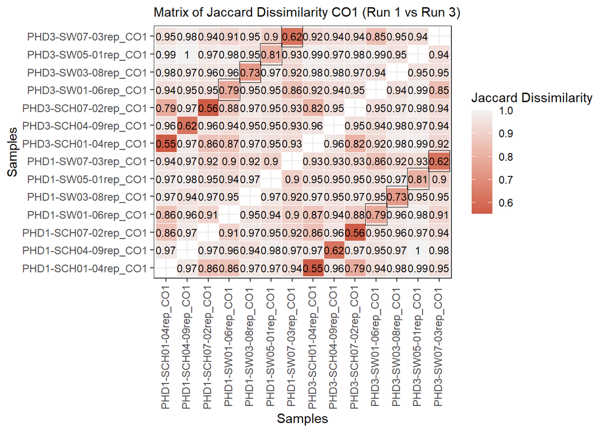

```r
# Dissimilarity
#Jaccard dissimilarity (based on P/A) - high value = most different
replicates_run1v3_phylo <- phylo_eDNA_decontam_filtered %>%
  subset_samples(fullID %in% sample_order_run1v3) # subset phylo

run_replicates_dis_jaccard_1v3 <- as.matrix(distance(replicates_run1v3_phylo, "jaccard", binary = TRUE)) # run analyses

# format matrix to long
longData<-melt(run_replicates_dis_jaccard_1v3)
longData<-longData[longData$value!=0,]

# Add TRUE or FALSE variable for replicates (same as previous)
longData$replicate <- ifelse(sapply(longData$Var1, extract_middle_CO1) == sapply(longData$Var2, extract_middle_CO1), TRUE, FALSE)

#plot matrix (CO1)
dis_CO1_matrix_run1v3 <- ggplot(longData, aes(x = Var2, y = Var1)) +
  geom_tile(aes(fill = value), color = "white") +
  geom_point(data = subset(longData, replicate == TRUE),
             aes(x = Var2, y = Var1),
             color = "black", size = 8, shape = 0, fill = NA) +
  geom_text(aes(label = round(value, 2)), color = "black", size = 3) + # Add text labels
  scale_fill_gradient(low = "coral3", high = "grey95", name = "Jaccard Dissimilarity") +
  labs(x = "Samples", y = "Samples", title = "Matrix of Jaccard Dissimilarity CO1 (Run 1 vs Run 3)") +
  theme_bw() +
  theme(axis.text.x = element_text(size = 9, angle = 90, vjust = 0.3),
        axis.text.y = element_text(size = 9),
        plot.title = element_text(size = 11))

dis_CO1_matrix_run1v3
```

```r
ggsave(filename = "Figures/dis_CO1_matrix_run1v3_curated_98.png", plot = dis_CO1_matrix_run1v3 ,
       device = "png", dpi = 300, units = "mm", height = 200, width = 250)
```

For run 2 and run 3.

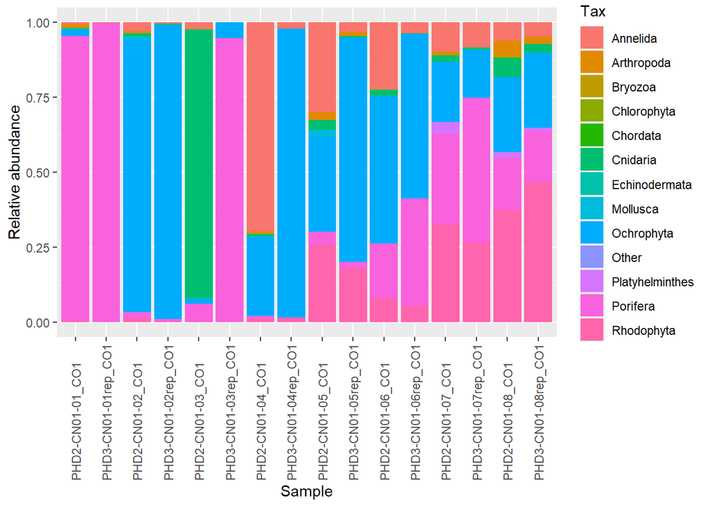

```r
# Comparison taxa plot
run_replicates_taxa_plot_2v3 <- microbiome::plot_composition(phylum_pseq) +
  xlab("Sample") + ylab("Relative abundance")+
  scale_x_discrete(limits = c(sample_order_run2v3))

run_replicates_taxa_plot_2v3
```

```r
ggsave(filename = "Figures/run_replicates_taxa_plot_2v3_curated_98.png", plot = run_replicates_taxa_plot_2v3,
       device = "png", dpi = 300, units = "mm", height = 200, width = 450)
```

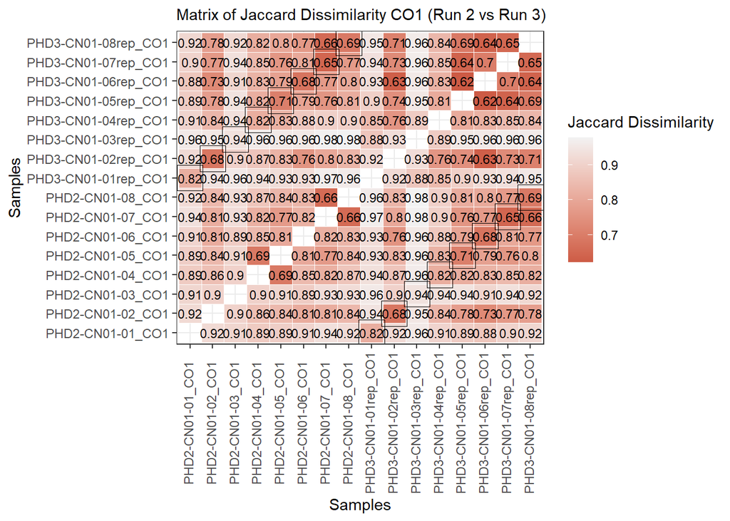

```r
#Dissimilarity
#Jaccard dissimilarity (based on P/A) - high value = most different
replicates_run2v3_phylo <- phylo_eDNA_decontam_filtered %>% subset_samples(fullID %in% sample_order_run2v3) # subset phylo
run_replicates_dis_jaccard_2v3 <- as.matrix(distance(replicates_run2v3_phylo, "jaccard", binary = TRUE)) # run analyses

# format matrix to long
longData<-melt(run_replicates_dis_jaccard_2v3)
longData<-longData[longData$value!=0,]

# Add TRUE or FALSE variable for replicates
longData$replicate <- ifelse(sapply(longData$Var1, extract_middle_CO1) == sapply(longData$Var2, extract_middle_CO1), TRUE, FALSE)

#plot matrix (CO1)
dis_CO1_matrix_run2v3 <- ggplot(longData, aes(x = Var2, y = Var1)) +
  geom_tile(aes(fill = value), color = "white") +
  geom_point(data = subset(longData, replicate == TRUE),
             aes(x = Var2, y = Var1),
             color = "black", size = 8, shape = 0, fill = NA) +
  geom_text(aes(label = round(value, 2)), color = "black", size = 3) + # Add text labels
  scale_fill_gradient(low = "coral3", high = "grey95", name = "Jaccard Dissimilarity") +
  labs(x = "Samples", y = "Samples", title = "Matrix of Jaccard Dissimilarity CO1 (Run 2 vs Run 3)") +
  theme_bw() +
  theme(axis.text.x = element_text(size = 9, angle = 90, vjust = 0.3),
        axis.text.y = element_text(size = 9),
        plot.title = element_text(size = 11))

dis_CO1_matrix_run2v3
```

```r
ggsave(filename = "Figures/dis_CO1_matrix_run2v3_curated_98.png", plot = dis_CO1_matrix_run2v3 ,
       device = "png", dpi = 300, units = "mm", height = 200, width = 250)
```

#### Within runs (by site)

We first set the order our our samples within each region.

```r
SCH_reps <- c(
  "PHD1-SCH01-04_CO1",
  "PHD1-SCH01-04rep_CO1",
  "PHD1-SCH04-09_CO1",
  "PHD1-SCH04-09rep_CO1",
  "PHD1-SCH07-02_CO1",
  "PHD1-SCH07-02rep_CO1",
  "PHD1-SCH01-04_18S",
  "PHD1-SCH01-04rep_18S",
  "PHD1-SCH03-05_18S",
  "PHD1-SCH03-05rep_18S",
  "PHD1-SCH04-09_18S",
  "PHD1-SCH04-09rep_18S",
  "PHD1-SCH07-02_18S",
  "PHD1-SCH07-02rep_18S"
)

SW_reps <- c(
  "PHD1-SW01-06_CO1",
  "PHD1-SW01-06rep_CO1",
  "PHD1-SW03-08_CO1",
  "PHD1-SW03-08rep_CO1",
  "PHD1-SW05-01_CO1",
  "PHD1-SW05-01rep_CO1",
  "PHD1-SW05-02_CO1",
  "PHD1-SW05-02rep_CO1",
  "PHD1-SW05-03_CO1",
  "PHD1-SW05-03rep_CO1",
  "PHD1-SW07-03_CO1",
  "PHD1-SW07-03rep_CO1",
  "PHD1-SW01-06_18S",
  "PHD1-SW01-06rep_18S",
  "PHD1-SW03-08_18S",
  "PHD1-SW03-08rep_18S",
  "PHD1-SW05-01_18S",
  "PHD1-SW05-01rep_18S",
  "PHD1-SW05-02_18S",
  "PHD1-SW07-03_18S",
  "PHD1-SW07-03rep_18S"
)

NW_reps <- c(
  "PHD2-NW01-02_CO1",
  "PHD2-NW01-02rep_CO1",
  "PHD2-NW03-08_CO1",
  "PHD2-NW03-08rep_CO1",
  "PHD2-NW06-02_CO1",
  "PHD2-NW06-02rep_CO1",
  "PHD2-NW01-02_18S",
  "PHD2-NW01-02rep_18S",
  "PHD2-NW03-08_18S",
  "PHD2-NW03-08rep_18S",
  "PHD2-NW06-02_18S",
  "PHD2-NW06-02rep_18S"
  )

CN_reps <- c(
  "PHD2-CN02-09_CO1",
  "PHD2-CN02-09rep_CO1",
  "PHD2-CN04-05_CO1",
  "PHD2-CN04-05rep_CO1",
  "PHD2-CN05-08_CO1",
  "PHD2-CN05-08rep_CO1",
  "PHD2-CN02-09_18S",
  "PHD2-CN02-09rep_18S",
  "PHD2-CN04-05_18S",
  "PHD2-CN04-05rep_18S",
  "PHD2-CN05-08_18S",
  "PHD2-CN05-08rep_18S"
  )

NE_reps <- c(
  "PHD2-NE02-09_CO1",
  "PHD2-NE02-09rep_CO1",
  "PHD2-NE04-05_CO1",
  "PHD2-NE04-05rep_CO1",
  "PHD2-NE05-08_CO1",
  "PHD2-NE05-08rep_CO1",
  "PHD2-NE02-09_18S",
  "PHD2-NE02-09rep_18S",
  "PHD2-NE04-05_18S",
  "PHD2-NE04-05rep_18S",
  "PHD2-NE05-08_18S",
  "PHD2-NE05-08rep_18S")
```

South Wales

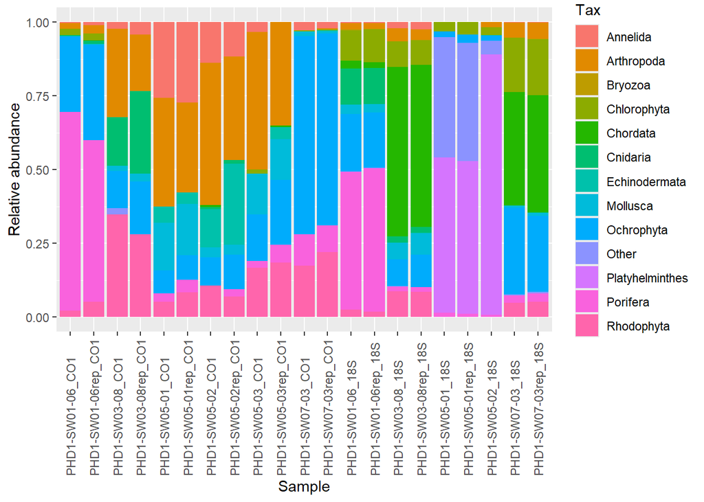

```r
#### Comparison taxa plot
run_replicates_taxa_plot_SW <- microbiome::plot_composition(phylum_pseq) +
  xlab("Sample") + ylab("Relative abundance")+
  scale_x_discrete(limits = c(SW_reps))

run_replicates_taxa_plot_SW
```

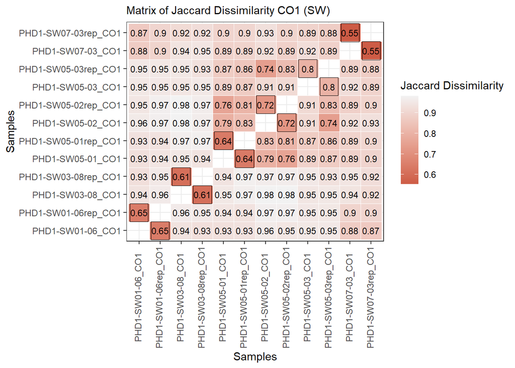

```r
#### Dissimilarity

#Jaccard dissimilarity (based on P/A) - high value = most different
replicates_SW_phylo <- phylo_eDNA_decontam_filtered %>% subset_samples(fullID %in% SW_reps) # subset phylo
run_replicates_dis_jaccard_SW <- as.matrix(distance(replicates_SW_phylo, "jaccard", binary = TRUE)) # run analyses

# format matrix to long
longData<-melt(run_replicates_dis_jaccard_SW)
longData<-longData[longData$value!=0,]

# Add TRUE or FALSE variable for replicates
longData$replicate <- ifelse(sapply(longData$Var1, extract_middle) == sapply(longData$Var2, extract_middle), TRUE, FALSE)

# Extract the last section of the sample names
longData$primerVar1 <- sub(".*_(18S|CO1)$", "\\1", longData$Var1)
longData$primerVar2 <- sub(".*_(18S|CO1)$", "\\1", longData$Var2)
longData_sameprimer <- filter(longData, primerVar1 == primerVar2)

#Individual primer datasets
longData18S <- subset(longData_sameprimer, primerVar1 == "18S")
longDataCO1 <- subset(longData_sameprimer, primerVar1 == "CO1")

#plot matrix (CO1)
dis_CO1_matrix_SW <- ggplot(longDataCO1, aes(x = Var2, y = Var1)) +
  geom_tile(aes(fill = value), color = "white") +
  geom_point(data = subset(longDataCO1, replicate == TRUE),
             aes(x = Var2, y = Var1),
             color = "black", size = 8, shape = 0, fill = NA) +
  geom_text(aes(label = round(value, 2)), color = "black", size = 3) + # Add text labels
  scale_fill_gradient(low = "coral3", high = "grey95", name = "Jaccard Dissimilarity") +
  labs(x = "Samples", y = "Samples", title = "Matrix of Jaccard Dissimilarity CO1 (SW)") +
  theme_bw() +
  theme(axis.text.x = element_text(size = 9, angle = 90, vjust = 0.3),
        axis.text.y = element_text(size = 9),
        plot.title = element_text(size = 11))

dis_CO1_matrix_SW
```

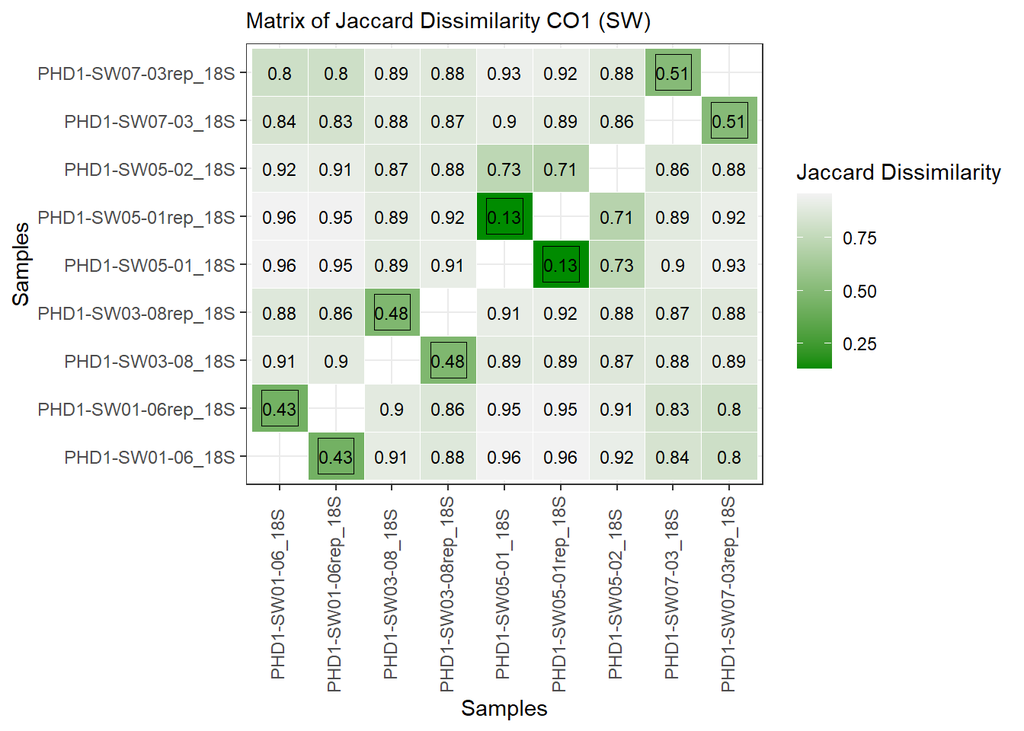

```r
ggsave(filename = "Figures/PCR_replicates/dis_CO1_matrix_SW_curated_98.png", plot = dis_CO1_matrix_SW ,
       device = "png", dpi = 300, units = "mm", height = 200, width = 250)

#plot matrix (18S)
dis_18S_matrix_SW <- ggplot(longData18S, aes(x = Var2, y = Var1)) +
  geom_tile(aes(fill = value), color = "white") +
  geom_point(data = subset(longData18S, replicate == TRUE),
             aes(x = Var2, y = Var1),
             color = "black", size = 8, shape = 0, fill = NA) +
  geom_text(aes(label = round(value, 2)), color = "black", size = 3) + # Add text labels
  scale_fill_gradient(low = "green4", high = "grey95", name = "Jaccard Dissimilarity") +
  labs(x = "Samples", y = "Samples", title = "Matrix of Jaccard Dissimilarity CO1 (SW)") +
  theme_bw() +
  theme(axis.text.x = element_text(size = 9, angle = 90, vjust = 0.3),
        axis.text.y = element_text(size = 9),
        plot.title = element_text(size = 11))

dis_18S_matrix_SW
```

```r
ggsave(filename = "Figures/PCR_replicates/dis_18S_matrix_SW_curated_98.png", plot = dis_18S_matrix_SW ,
       device = "png", dpi = 300, units = "mm", height = 200, width = 250)
```

Scotland

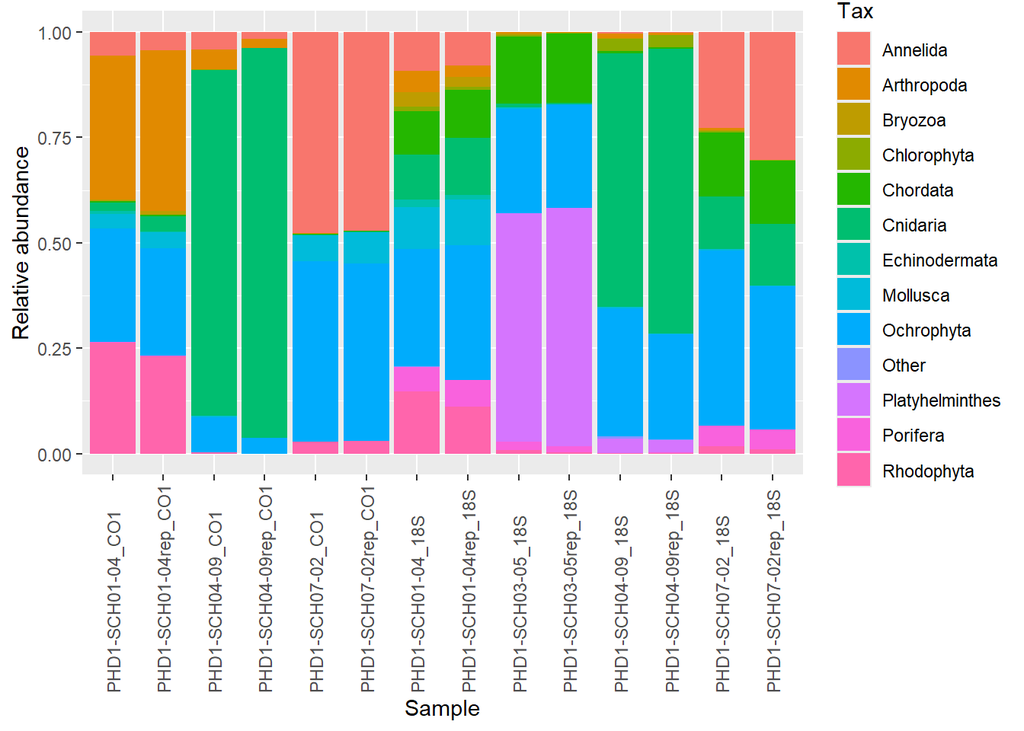

```r
#### Comparison taxa plot
run_replicates_taxa_plot_SCH <- microbiome::plot_composition(phylum_pseq) +
  xlab("Sample") + ylab("Relative abundance")+
  scale_x_discrete(limits = c(SCH_reps))

run_replicates_taxa_plot_SCH
```

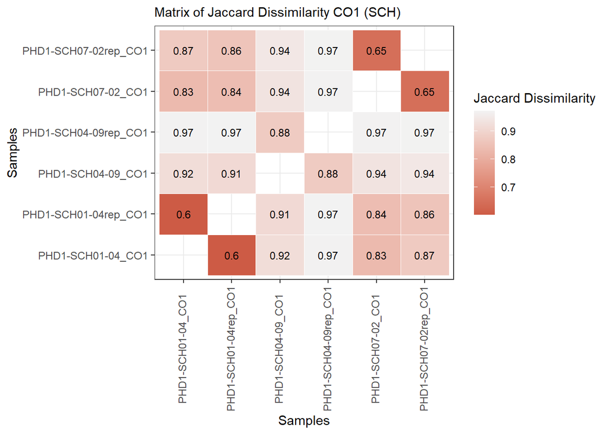

```r
#### Dissimilarity

#Jaccard dissimilarity (based on P/A) - high value = most different
replicates_SCH_phylo <- phylo_eDNA_decontam_filtered %>% subset_samples(fullID %in% SCH_reps) # subset phylo
run_replicates_dis_jaccard_SCH <- as.matrix(distance(replicates_SCH_phylo, "jaccard", binary = TRUE)) # run analyses

# format matrix to long
longData<-melt(run_replicates_dis_jaccard_SCH)
longData<-longData[longData$value!=0,]

# Add TRUE or FALSE variable for replicates
longData$replicate <- ifelse(sapply(longData$Var1, extract_middle) == sapply(longData$Var2, extract_middle), TRUE, FALSE)

# Extract the last section of the sample names
longData$primerVar1 <- sub(".*_(18S|CO1)$", "\\1", longData$Var1)
longData$primerVar2 <- sub(".*_(18S|CO1)$", "\\1", longData$Var2)
longData_sameprimer <- filter(longData, primerVar1 == primerVar2)

#Individual primer datasets
longData18S <- subset(longData_sameprimer, primerVar1 == "18S")
longDataCO1 <- subset(longData_sameprimer, primerVar1 == "CO1")

#plot matrix (CO1)
dis_CO1_matrix_SCH <- ggplot(longDataCO1, aes(x = Var2, y = Var1)) +
  geom_tile(aes(fill = value), color = "white") +
  geom_point(data = subset(longDataCO1, replicate == TRUE),
             aes(x = Var2, y = Var1),
             color = "black", size = 8, shape = 0, fill = NA) +
  geom_text(aes(label = round(value, 2)), color = "black", size = 3) + # Add text labels
  scale_fill_gradient(low = "coral3", high = "grey95", name = "Jaccard Dissimilarity") +
  labs(x = "Samples", y = "Samples", title = "Matrix of Jaccard Dissimilarity CO1 (SCH)") +
  theme_bw() +
  theme(axis.text.x = element_text(size = 9, angle = 90, vjust = 0.3),
        axis.text.y = element_text(size = 9),
        plot.title = element_text(size = 11))

dis_CO1_matrix_SCH
```

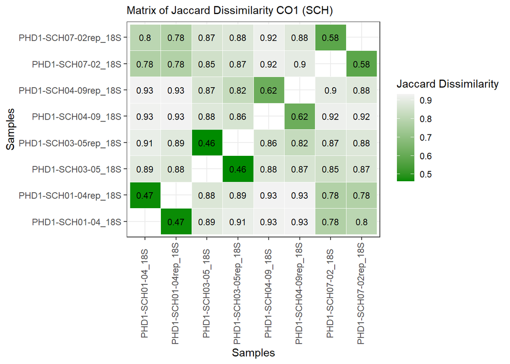

```r
ggsave(filename = "Figures/PCR_replicates/dis_CO1_matrix_SCH_curated_98.png", plot = dis_CO1_matrix_SCH ,
       device = "png", dpi = 300, units = "mm", height = 150, width = 250)

#plot matrix (18S)
dis_18S_matrix_SCH<- ggplot(longData18S, aes(x = Var2, y = Var1)) +
  geom_tile(aes(fill = value), color = "white") +
  geom_point(data = subset(longData18S, replicate == TRUE),
             aes(x = Var2, y = Var1),
             color = "black", size = 8, shape = 0, fill = NA) +
  geom_text(aes(label = round(value, 2)), color = "black", size = 3) + # Add text labels
  scale_fill_gradient(low = "green4", high = "grey95", name = "Jaccard Dissimilarity") +
  labs(x = "Samples", y = "Samples", title = "Matrix of Jaccard Dissimilarity CO1 (SCH)") +
  theme_bw() +
  theme(axis.text.x = element_text(size = 9, angle = 90, vjust = 0.3),
        axis.text.y = element_text(size = 9),
        plot.title = element_text(size = 11))

dis_18S_matrix_SCH
```

```r
ggsave(filename = "Figures/PCR_replicates/dis_18S_matrix_SCH_curated_98.png", plot = dis_18S_matrix_SCH ,
       device = "png", dpi = 300, units = "mm", height = 200, width = 250)
```

Cornwall

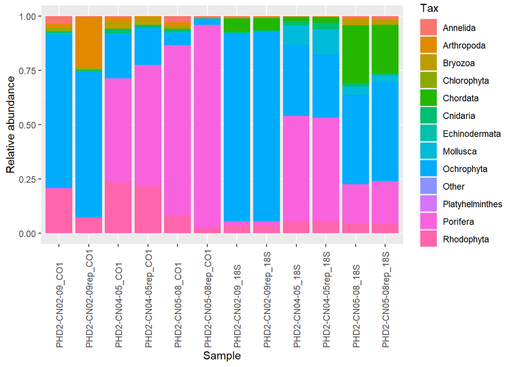

```r
#### Comparison taxa plot
run_replicates_taxa_plot_CN <- microbiome::plot_composition(phylum_pseq) +
  xlab("Sample") + ylab("Relative abundance")+
  scale_x_discrete(limits = c(CN_reps))

run_replicates_taxa_plot_CN
```

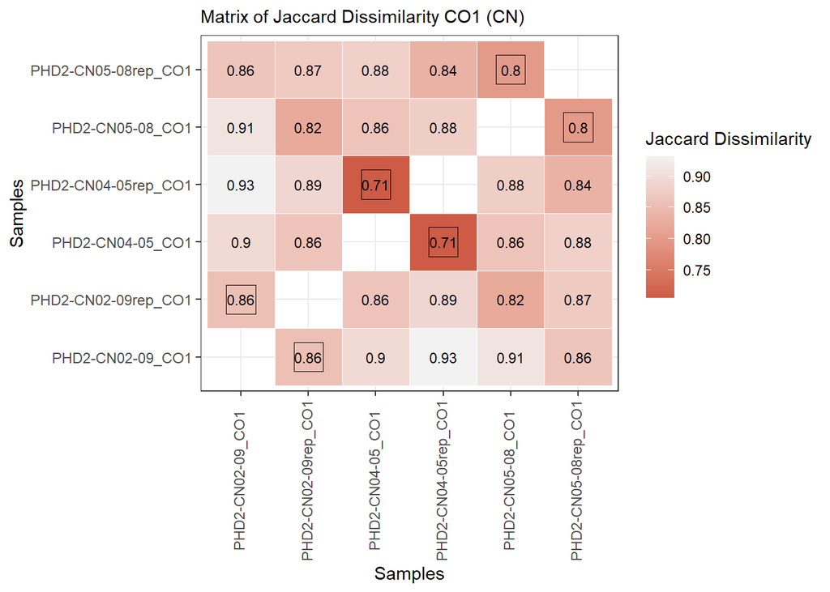

```r
#### Dissimilarity

#Jaccard dissimilarity (based on P/A) - high value = most different
replicates_CN_phylo <- phylo_eDNA_decontam_filtered %>% subset_samples(fullID %in% CN_reps) # subset phylo
run_replicates_dis_jaccard_CN <- as.matrix(distance(replicates_CN_phylo, "jaccard", binary = TRUE)) # run analyses

# format matrix to long
longData<-melt(run_replicates_dis_jaccard_CN)
longData<-longData[longData$value!=0,]

# Add TRUE or FALSE variable for replicates
longData$replicate <- ifelse(sapply(longData$Var1, extract_middle) == sapply(longData$Var2, extract_middle), TRUE, FALSE)

# Extract the last section of the sample names
longData$primerVar1 <- sub(".*_(18S|CO1)$", "\\1", longData$Var1)
longData$primerVar2 <- sub(".*_(18S|CO1)$", "\\1", longData$Var2)
longData_sameprimer <- filter(longData, primerVar1 == primerVar2)

#Individual primer datasets
longData18S <- subset(longData_sameprimer, primerVar1 == "18S")
longDataCO1 <- subset(longData_sameprimer, primerVar1 == "CO1")

#plot matrix (CO1)
dis_CO1_matrix_CN <- ggplot(longDataCO1, aes(x = Var2, y = Var1)) +
  geom_tile(aes(fill = value), color = "white") +
  geom_point(data = subset(longDataCO1, replicate == TRUE),
             aes(x = Var2, y = Var1),
             color = "black", size = 8, shape = 0, fill = NA) +
  geom_text(aes(label = round(value, 2)), color = "black", size = 3) + # Add text labels
  scale_fill_gradient(low = "coral3", high = "grey95", name = "Jaccard Dissimilarity") +
  labs(x = "Samples", y = "Samples", title = "Matrix of Jaccard Dissimilarity CO1 (CN)") +
  theme_bw() +
  theme(axis.text.x = element_text(size = 9, angle = 90, vjust = 0.3),
        axis.text.y = element_text(size = 9),
        plot.title = element_text(size = 11))

dis_CO1_matrix_CN
```

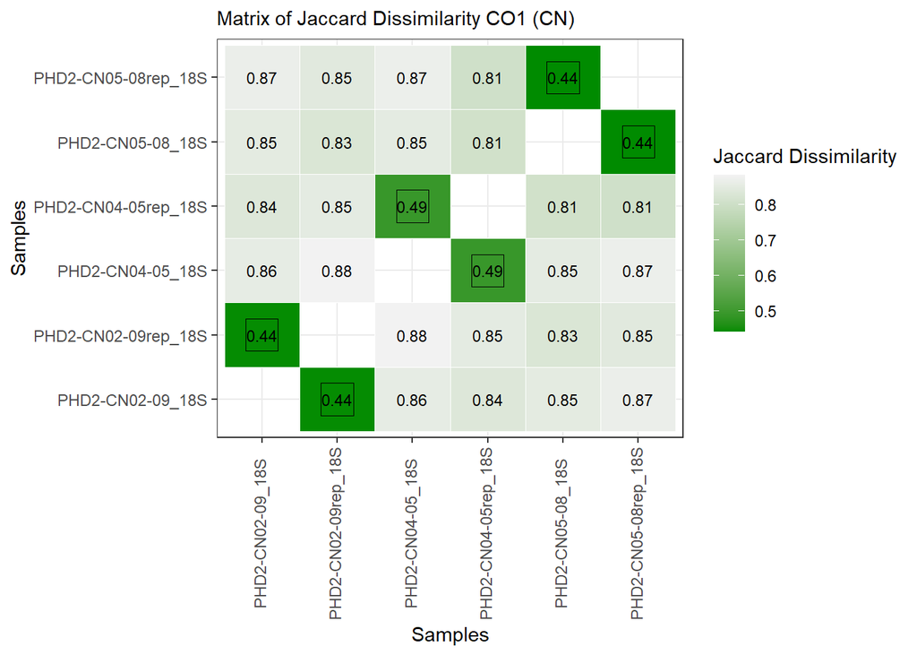

```r
ggsave(filename = "Figures/PCR_replicates/dis_CO1_matrix_CN_curated_98.png", plot = dis_CO1_matrix_CN ,
       device = "png", dpi = 300, units = "mm", height = 200, width = 250)

#plot matrix (18S)
dis_18S_matrix_CN <- ggplot(longData18S, aes(x = Var2, y = Var1)) +
  geom_tile(aes(fill = value), color = "white") +
  geom_point(data = subset(longData18S, replicate == TRUE),
             aes(x = Var2, y = Var1),
             color = "black", size = 8, shape = 0, fill = NA) +
  geom_text(aes(label = round(value, 2)), color = "black", size = 3) + # Add text labels
  scale_fill_gradient(low = "green4", high = "grey95", name = "Jaccard Dissimilarity") +
  labs(x = "Samples", y = "Samples", title = "Matrix of Jaccard Dissimilarity CO1 (CN)") +
  theme_bw() +
  theme(axis.text.x = element_text(size = 9, angle = 90, vjust = 0.3),
        axis.text.y = element_text(size = 9),
        plot.title = element_text(size = 11))

dis_18S_matrix_CN
```

```r
ggsave(filename = "Figures/PCR_replicates/dis_18S_matrix_CN_curated_98.png", plot = dis_18S_matrix_CN ,
       device = "png", dpi = 300, units = "mm", height = 200, width = 250)
```

Northeast England

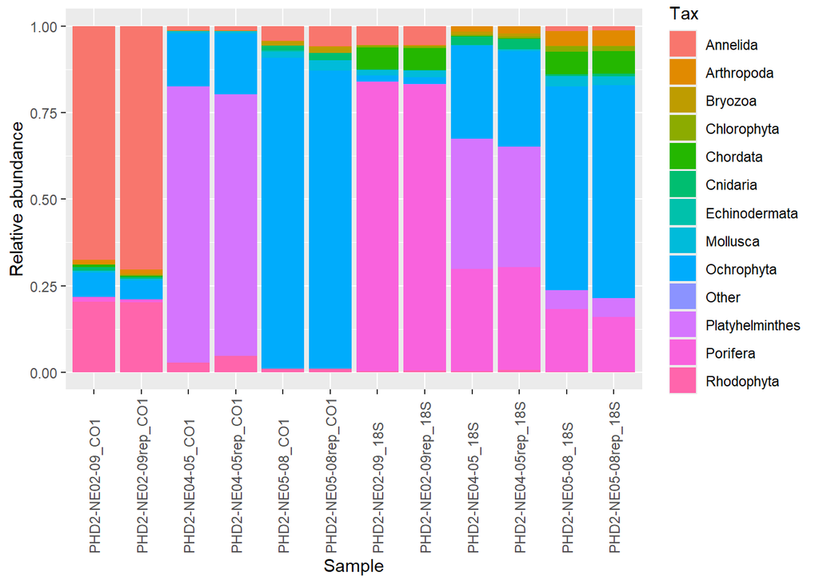

```r
#### Comparison taxa plot
run_replicates_taxa_plot_NE <- microbiome::plot_composition(phylum_pseq) +
  xlab("Sample") + ylab("Relative abundance")+
  scale_x_discrete(limits = c(NE_reps))

run_replicates_taxa_plot_NE
```

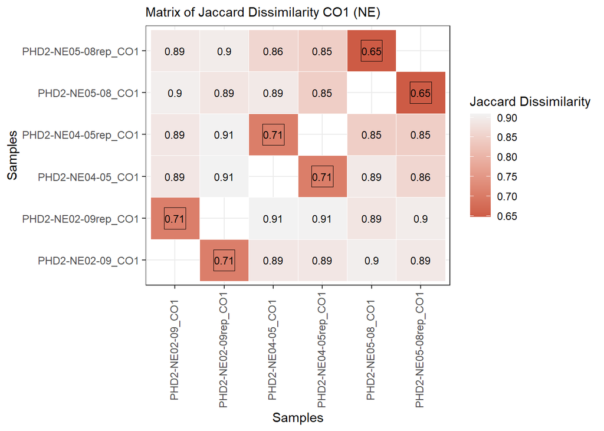

```r
#### Dissimilarity

#Jaccard dissimilarity (based on P/A) - high value = most different
replicates_NE_phylo <- phylo_eDNA_decontam_filtered %>% subset_samples(fullID %in% NE_reps) # subset phylo
run_replicates_dis_jaccard_NE <- as.matrix(distance(replicates_NE_phylo, "jaccard", binary = TRUE)) # run analyses

# format matrix to long
longData<-melt(run_replicates_dis_jaccard_NE)
longData<-longData[longData$value!=0,]

# Add TRUE or FALSE variable for replicates
longData$replicate <- ifelse(sapply(longData$Var1, extract_middle) == sapply(longData$Var2, extract_middle), TRUE, FALSE)

# Extract the last section of the sample names
longData$primerVar1 <- sub(".*_(18S|CO1)$", "\\1", longData$Var1)
longData$primerVar2 <- sub(".*_(18S|CO1)$", "\\1", longData$Var2)
longData_sameprimer <- filter(longData, primerVar1 == primerVar2)

#Individual primer datasets
longData18S <- subset(longData_sameprimer, primerVar1 == "18S")
longDataCO1 <- subset(longData_sameprimer, primerVar1 == "CO1")

#plot matrix (CO1)
dis_CO1_matrix_NE <- ggplot(longDataCO1, aes(x = Var2, y = Var1)) +
  geom_tile(aes(fill = value), color = "white") +
  geom_point(data = subset(longDataCO1, replicate == TRUE),
             aes(x = Var2, y = Var1),
             color = "black", size = 8, shape = 0, fill = NA) +
  geom_text(aes(label = round(value, 2)), color = "black", size = 3) + # Add text labels
  scale_fill_gradient(low = "coral3", high = "grey95", name = "Jaccard Dissimilarity") +
  labs(x = "Samples", y = "Samples", title = "Matrix of Jaccard Dissimilarity CO1 (NE)") +
  theme_bw() +
  theme(axis.text.x = element_text(size = 9, angle = 90, vjust = 0.3),
        axis.text.y = element_text(size = 9),
        plot.title = element_text(size = 11))

dis_CO1_matrix_NE
```

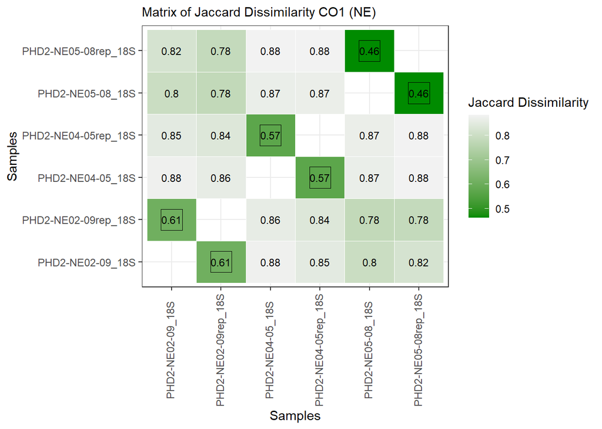

```r
ggsave(filename = "Figures/PCR_replicates/dis_CO1_matrix_NE_curated_98.png", plot = dis_CO1_matrix_NE,
       device = "png", dpi = 300, units = "mm", height = 200, width = 250)

#plot matrix (18S)
dis_18S_matrix_NE <- ggplot(longData18S, aes(x = Var2, y = Var1)) +
  geom_tile(aes(fill = value), color = "white") +
  geom_point(data = subset(longData18S, replicate == TRUE),
             aes(x = Var2, y = Var1),
             color = "black", size = 8, shape = 0, fill = NA) +
  geom_text(aes(label = round(value, 2)), color = "black", size = 3) + # Add text labels
  scale_fill_gradient(low = "green4", high = "grey95", name = "Jaccard Dissimilarity") +
  labs(x = "Samples", y = "Samples", title = "Matrix of Jaccard Dissimilarity CO1 (NE)") +
  theme_bw() +
  theme(axis.text.x = element_text(size = 9, angle = 90, vjust = 0.3),
        axis.text.y = element_text(size = 9),
        plot.title = element_text(size = 11))

dis_18S_matrix_NE
```

```r
ggsave(filename = "Figures/PCR_replicates/dis_18S_matrix_NE_curated_98.png", plot = dis_18S_matrix_NE ,
       device = "png", dpi = 300, units = "mm", height = 200, width = 250)
```

North Wales

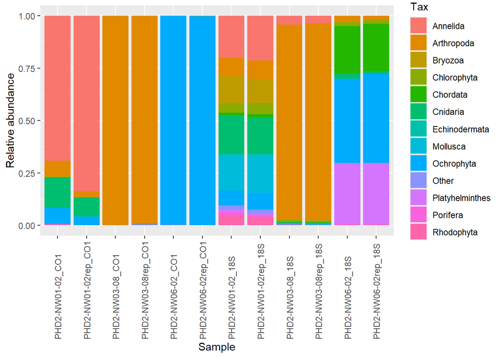

```r
#### Comparison taxa plot
run_replicates_taxa_plot_NW <- microbiome::plot_composition(phylum_pseq) +
  xlab("Sample") + ylab("Relative abundance")+
  scale_x_discrete(limits = c(NW_reps))

run_replicates_taxa_plot_NW
```

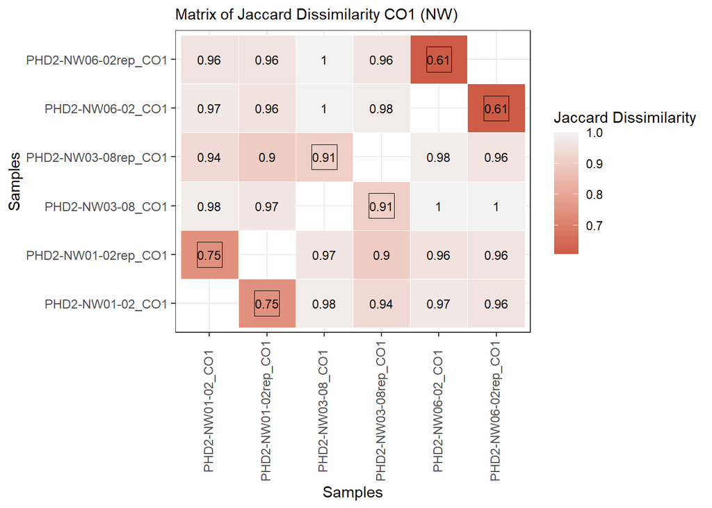

```r
#### Dissimilarity

#Jaccard dissimilarity (based on P/A) - high value = most different
replicates_NW_phylo <- phylo_eDNA_decontam_filtered %>% subset_samples(fullID %in% NW_reps) # subset phylo
run_replicates_dis_jaccard_NW <- as.matrix(distance(replicates_NW_phylo, "jaccard", binary = TRUE)) # run analyses

# format matrix to long
longData<-melt(run_replicates_dis_jaccard_NW)
longData<-longData[longData$value!=0,]

# Add TRUE or FALSE variable for replicates
longData$replicate <- ifelse(sapply(longData$Var1, extract_middle) == sapply(longData$Var2, extract_middle), TRUE, FALSE)

# Extract the last section of the sample names
longData$primerVar1 <- sub(".*_(18S|CO1)$", "\\1", longData$Var1)
longData$primerVar2 <- sub(".*_(18S|CO1)$", "\\1", longData$Var2)
longData_sameprimer <- filter(longData, primerVar1 == primerVar2)

#Individual primer datasets
longData18S <- subset(longData_sameprimer, primerVar1 == "18S")
longDataCO1 <- subset(longData_sameprimer, primerVar1 == "CO1")

#plot matrix (CO1)
dis_CO1_matrix_NW <- ggplot(longDataCO1, aes(x = Var2, y = Var1)) +
  geom_tile(aes(fill = value), color = "white") +
  geom_point(data = subset(longDataCO1, replicate == TRUE),
             aes(x = Var2, y = Var1),
             color = "black", size = 8, shape = 0, fill = NA) +
  geom_text(aes(label = round(value, 2)), color = "black", size = 3) + # Add text labels
  scale_fill_gradient(low = "coral3", high = "grey95", name = "Jaccard Dissimilarity") +
  labs(x = "Samples", y = "Samples", title = "Matrix of Jaccard Dissimilarity CO1 (NW)") +
  theme_bw() +
  theme(axis.text.x = element_text(size = 9, angle = 90, vjust = 0.3),
        axis.text.y = element_text(size = 9),
        plot.title = element_text(size = 11))

dis_CO1_matrix_NW
```

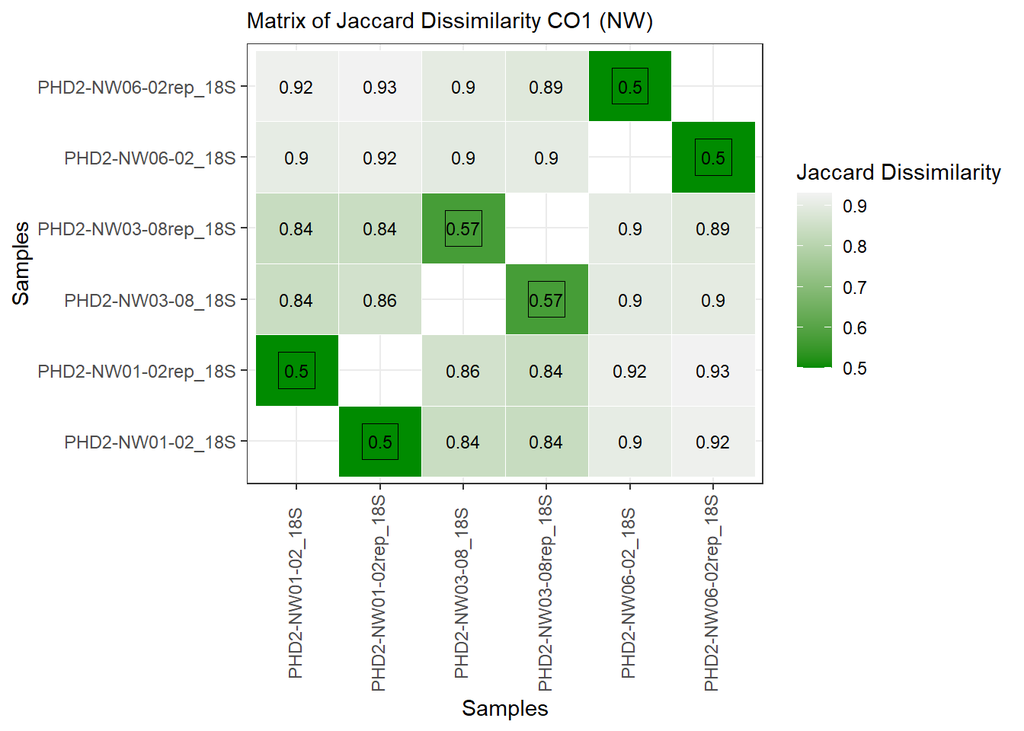

```r
ggsave(filename = "Figures/PCR_replicates/dis_CO1_matrix_NW_curated_98.png", plot = dis_CO1_matrix_NW,
       device = "png", dpi = 300, units = "mm", height = 200, width = 250)

#plot matrix (18S)
dis_18S_matrix_NW <- ggplot(longData18S, aes(x = Var2, y = Var1)) +
  geom_tile(aes(fill = value), color = "white") +
  geom_point(data = subset(longData18S, replicate == TRUE),
             aes(x = Var2, y = Var1),
             color = "black", size = 8, shape = 0, fill = NA) +
  geom_text(aes(label = round(value, 2)), color = "black", size = 3) + # Add text labels
  scale_fill_gradient(low = "green4", high = "grey95", name = "Jaccard Dissimilarity") +
  labs(x = "Samples", y = "Samples", title = "Matrix of Jaccard Dissimilarity CO1 (NW)") +
  theme_bw() +
  theme(axis.text.x = element_text(size = 9, angle = 90, vjust = 0.3),
        axis.text.y = element_text(size = 9),
        plot.title = element_text(size = 11))

dis_18S_matrix_NW
```

```r
ggsave(filename = "Figures/PCR_replicates/dis_18S_matrix_NW_curated_98.png", plot = dis_18S_matrix_NW,
       device = "png", dpi = 300, units = "mm", height = 200, width = 250)
```

Join comp plots together for export.

[figure not shown]

```r
all_region_reps <- cowplot::plot_grid(
  run_replicates_taxa_plot_NW + theme(legend.position = "none"),
  run_replicates_taxa_plot_SW + theme(legend.position =
                                        "none"),
  run_replicates_taxa_plot_SCH + theme(legend.position =
                                         "none"),
  run_replicates_taxa_plot_CN ,
  run_replicates_taxa_plot_NE + theme(legend.position =
                                        "none"),
  labels = c("a", "b", "c", "d", "e"),
  ncol = 2,
  align = "hv"
)

all_region_reps
```

```r
ggsave(filename = "Figures/all_region_reps.png", plot = all_region_reps,
       device = "png", dpi = 300, units = "mm", height = 350, width = 270)
```

#### Within shore heights

We need to get a list of sites for the following loop.

```r
site_ids <- unique(sample_data(phylo_eDNA_decontam_filtered)$localityID) %>% na.omit() # Add more site IDs as needed
```

Similar to above, we need to calculate the relative abundances, but this time for the whole data set.

```r
#Transform abundance table to a relative abundance (compositional) table
pseq_relabund <- microbiome::transform(phylo_eDNA_decontam_filtered, "compositional")

#Phylum phyloseq
phylum_pseq <- microbiome::aggregate_taxa(pseq_relabund, "phylum", verbose = FALSE)
```

Generate plots for COI samples.

```r
#CO1 plots
# Define a function to generate and save the taxa plot for a given site
generate_taxa_plot_CO1 <- function(site_id) {

  # Subset samples for the given site
  site_samples_CO1 <- subset_samples(phylo_eDNA_decontam_filtered, localityID == site_id & primer == 'CO1')
  sample_names_CO1 <- sample_names(site_samples_CO1)

  # Extract the shorePosition variable
  shore_positions <- sample_data(site_samples_CO1)$shorePosition
  names(shore_positions) <- sample_names_CO1

  # Generate the taxa plot
  taxa_plot <- microbiome::plot_composition(phylum_pseq) +
    xlab("Sample") + ylab("Relative abundance") +
    scale_x_discrete(limits = sample_names_CO1)

  # Save the plot
  ggsave(
    filename = paste0(
      "Figures/field_replicates/CO1/field_replicates_taxa_plot_",
      site_id,
      "_CO1.png"
    ),
    plot = taxa_plot,
    device = "png",
    dpi = 300,
    units = "mm",
    height = 200,
    width = 450
  )
}

# Loop through each site ID and generate the plot
for (site_id in site_ids) {
  generate_taxa_plot_CO1(site_id)
}
```

And for 18S samples.

```r
#18S plots
# Define a function to generate and save the taxa plot for a given site
generate_taxa_plot_18S <- function(site_id) {

  # Subset samples for the given site
  site_samples_18S <- subset_samples(phylo_eDNA_decontam_filtered, localityID == site_id & primer == '18S')
  sample_names_18S <- sample_names(site_samples_18S)

  # Generate the taxa plot
  taxa_plot <- microbiome::plot_composition(phylum_pseq) +
    xlab("Sample") + ylab("Relative abundance") +
    scale_x_discrete(limits = sample_names_18S)

  # Save the plot
  ggsave(
    filename = paste0("Figures/field_replicates/18S/field_replicates_taxa_plot_", site_id, "_18S.png"),
    plot = taxa_plot,
    device = "png",
    dpi = 300,
    units = "mm",
    height = 200,
    width = 450
  )
}

# Loop through each site ID and generate the plot
for (site_id in site_ids) {
  generate_taxa_plot_18S(site_id)
}
```

Now dissimilarity for both primers.

```r
generate_dis_plot <- function(site_id) {

  # Subset samples for the given site
  site_samples <- subset_samples(phylo_eDNA_decontam_filtered, localityID == site_id)
  sample_names <- sample_names(site_samples)

  #Jaccard dissimilarity (based on P/A) - high value = most different
  site_dis_jaccard <- as.matrix(distance(site_samples, "jaccard", binary = TRUE)) # run analyses

  # format matrix to long
  longData<-melt(site_dis_jaccard)
  longData<-longData[longData$value!=0,]

  #Split primers
  # Extract the last section of the sample names
  longData$primerVar1 <- sub(".*_(18S|CO1)$", "\\1", longData$Var1)
  longData$primerVar2 <- sub(".*_(18S|CO1)$", "\\1", longData$Var2)
  longData_sameprimer <- filter(longData, primerVar1 == primerVar2)

  #Individual primer datasets
  longData18S <- subset(longData_sameprimer, primerVar1 == "18S")
  longDataCO1 <- subset(longData_sameprimer, primerVar1 == "CO1")

  #plot matrix (CO1)
  dis_CO1_matrix <- ggplot(longDataCO1, aes(x = Var2, y = Var1)) +
    geom_tile(aes(fill = value), color = "white") +
    geom_text(aes(label = round(value, 2)), color = "black", size = 3) + # Add text labels
    scale_fill_gradient(low = "coral3", high = "grey95", name = "Jaccard Dissimilarity") +
    labs(x = "Samples", y = "Samples", title = "Matrix of Jaccard Dissimilarity CO1") +
    theme_bw() +
    theme(axis.text.x = element_text(size = 9, angle = 90, vjust = 0.3),
          axis.text.y = element_text(size = 9),
          plot.title = element_text(size = 11))

  dis_CO1_matrix

  # Save the plot
  ggsave(
    filename = paste0("Figures/field_replicates/CO1/field_replicates_dis_plot_", site_id, "_CO1.png"),
    plot = dis_CO1_matrix,
    device = "png",
    dpi = 300,
    units = "mm",
    height = 200,
    width = 250
  )

  #plot matrix (18S)
  dis_18S_matrix <- ggplot(longData18S, aes(x = Var2, y = Var1)) +
    geom_tile(aes(fill = value), color = "white") +
    geom_text(aes(label = round(value, 2)), color = "black", size = 3) + # Add text labels
    scale_fill_gradient(low = "green4", high = "grey95", name = "Jaccard Dissimilarity") +
    labs(x = "Samples", y = "Samples", title = "Matrix of Jaccard Dissimilarity 18S") +
    theme_bw() +
    theme(axis.text.x = element_text(size = 9, angle = 90, vjust = 0.3),
          axis.text.y = element_text(size = 9),
          plot.title = element_text(size = 11))

  dis_18S_matrix

  # Save the plot
  ggsave(
    filename = paste0("Figures/field_replicates/18S/field_replicates_dis_plot_", site_id, "_18S.png"),
    plot = dis_18S_matrix,
    device = "png",
    dpi = 300,
    units = "mm",
    height = 200,
    width = 250
  )

}

# Loop through each site ID and generate the plot
for (site_id in site_ids) {
  generate_dis_plot(site_id)
}
```

#### Overall visualization of replicate dissimilarity

Let’s compare average dissimilarity across different replicate comparisons.

```r
phylo_replicates_pairs = subset_samples(phylo_eDNA_decontam_filtered, pairedRepLogical == TRUE)
phylo_replicates_pairs
```

```
phyloseq-class experiment-level object
otu_table()   OTU Table:         [ 1026 taxa and 119 samples ]
sample_data() Sample Data:       [ 119 samples by 42 sample variables ]
tax_table()   Taxonomy Table:    [ 1026 taxa by 13 taxonomic ranks ]
```

```r
# Identify the logical variable indicating replicates
jaccard_dissimilarity<- as.matrix(distance(phylo_replicates_pairs, "jaccard", binary = TRUE)) # run analyses

# format matrix to long
longData<-melt(jaccard_dissimilarity)
longData<-longData[longData$value!=0,]

# remove repeated combinations of var 1 and var 2
cols = c("Var1", "Var2")
longData <-longData[!duplicated(t(apply(longData[cols], 1, sort))), ]

# Add TRUE or FALSE variable for replicates
longData$replicate <- ifelse(sapply(longData$Var1, extract_middle_all) == sapply(longData$Var2, extract_middle_all), TRUE, FALSE)

# Extract the last section of the sample names
longData$primerVar1 <- sub(".*_(18S|CO1)$", "\\1", longData$Var1)
longData$primerVar2 <- sub(".*_(18S|CO1)$", "\\1", longData$Var2)
longData$sameprimer <- longData$primerVar1 == longData$primerVar2
longData$samesite <- extract_site(longData$Var1) == extract_site(longData$Var2)

longData_sameprimer <- filter(longData, primerVar1 == primerVar2)

#Individual primer datasets
longData18S <- subset(longData_sameprimer, primerVar1 == "18S")
longDataCO1 <- subset(longData_sameprimer, primerVar1 == "CO1")

#add sample type
meta_rep <- data.frame(sample_data(phylo_replicates_pairs))

meta_rep <- meta_rep %>%
  mutate(
    sampleType = case_when(
      fieldID == "PHD2-NE05-08rep" ~ "plate-replicate",  # Change if fieldID matches
      TRUE ~ sampleType  # Keep existing value otherwise
    )
  )

# add var1 type
longData <- longData %>%
  left_join(meta_rep %>% dplyr::select(fullID, sampleType),
            by = c("Var1" = "fullID")) %>%
  dplyr::rename(typeVar1 = sampleType)

# Joining var2 type
longData <- longData %>%
  dplyr::left_join(meta_rep %>% dplyr::select(fullID, sampleType),
            by = c("Var2" = "fullID")) %>%
  dplyr::rename(typeVar2 = sampleType)

longData$sametype <- longData$typeVar1 == longData$typeVar2
longData_sametype <- filter(longData, typeVar1 == typeVar2)

# define an overall type of the pairwise comparison for the plot and remove unneeded groups
longData <- longData %>%
  mutate(overallType = paste(pmin(typeVar1, typeVar2), pmax(typeVar1, typeVar2), sep = "-")) %>%
  filter(!grepl("failed-repeat", overallType)) %>%
  filter(!grepl("sample-sample", overallType)) %>%
  filter(!grepl("plate-replicate-plate-replicate", overallType))

# Plotting the boxplot using ggplot2
standard_error <- function(x) {
  sd(x, na.rm = TRUE) / sqrt(length(x))
}

# Calculate the averages for each group
averages <- longData %>%
  dplyr::group_by(replicate, samesite) %>%
  dplyr::summarise(mean_value = mean(value, na.rm = TRUE), .groups = 'drop',
                   standard_error = standard_error(value))

averages
```

```
# A tibble: 3 × 4
  replicate samesite mean_value standard_error
  <lgl>     <lgl>         <dbl>          <dbl>
1 FALSE     FALSE         0.963       0.000613
2 FALSE     TRUE          0.930       0.00533
3 TRUE      TRUE          0.667       0.0143
```

```r
compare_reps_jaccard_types <- ggplot(longData, aes(x = replicate, y = value, fill = overallType)) +
  geom_boxplot() +
  labs(x = "Replicate",
       y = "Jaccard Dissimilarity") +
  scale_fill_manual(values = c("plate-replicate-run-replicate" = "lightblue",
                               "plate-replicate-sample" = "lightgreen",
                               "run-replicate-run-replicate" = "gold",
                               "run-replicate-sample" = "pink"),
                    labels = c("plate-replicate-run-replicate" = "Plate replicate vs run replicate",
                               "plate-replicate-sample" = "Plate replicate vs sample",
                               "run-replicate-run-replicate" = "Run replicate vs run replicate",
                               "run-replicate-sample" = "Run replicate vs sample"),
                    name = "Replicate type") +
  theme_classic()+
  theme(legend.position = "none")
```

```r
# Identify the logical variable indicating replicates
bray_dissimilarity<- as.matrix(distance(phylo_replicates_pairs, "bray", binary = TRUE)) # run analyses

# format matrix to long
longData<-melt(bray_dissimilarity)
longData<-longData[longData$value!=0,]

# remove repeated combinations of var 1 and var 2
cols = c("Var1", "Var2")
longData <-longData[!duplicated(t(apply(longData[cols], 1, sort))), ]

# Add TRUE or FALSE variable for replicates
longData$replicate <- ifelse(sapply(longData$Var1, extract_middle_all) == sapply(longData$Var2, extract_middle_all), TRUE, FALSE)

# Extract the last section of the sample names
longData$primerVar1 <- sub(".*_(18S|CO1)$", "\\1", longData$Var1)
longData$primerVar2 <- sub(".*_(18S|CO1)$", "\\1", longData$Var2)
longData$sameprimer <- longData$primerVar1 == longData$primerVar2
longData$samesite <- extract_site(longData$Var1) == extract_site(longData$Var2)

longData_sameprimer <- filter(longData, primerVar1 == primerVar2)

#Individual primer datasets
longData18S <- subset(longData_sameprimer, primerVar1 == "18S")
longDataCO1 <- subset(longData_sameprimer, primerVar1 == "CO1")

#add sample type
meta_rep <- data.frame(sample_data(phylo_replicates_pairs))

meta_rep <- meta_rep %>%
  mutate(
    sampleType = case_when(
      fieldID == "PHD2-NE05-08rep" ~ "plate-replicate",  # Change if fieldID matches
      TRUE ~ sampleType  # Keep existing value otherwise
    )
  )

# add var1 type
longData <- longData %>%
  left_join(meta_rep %>% dplyr::select(fullID, sampleType),
            by = c("Var1" = "fullID")) %>%
  dplyr::rename(typeVar1 = sampleType)

# Joining var2 type
longData <- longData %>%
  dplyr::left_join(meta_rep %>% dplyr::select(fullID, sampleType),
                   by = c("Var2" = "fullID")) %>%
  dplyr::rename(typeVar2 = sampleType)

longData$sametype <- longData$typeVar1 == longData$typeVar2
longData_sametype <- filter(longData, typeVar1 == typeVar2)

# define an overall type of the pairwise comparison for the plot and remove unneeded groups
longData <- longData %>%
  mutate(overallType = paste(pmin(typeVar1, typeVar2), pmax(typeVar1, typeVar2), sep = "-")) %>%
  filter(!grepl("failed-repeat", overallType)) %>%
  filter(!grepl("sample-sample", overallType)) %>%
  filter(!grepl("plate-replicate-plate-replicate", overallType))

# Plotting the boxplot using ggplot2
standard_error <- function(x) {
  sd(x, na.rm = TRUE) / sqrt(length(x))
}

# Calculate the averages for each group
averages <- longData %>%
  dplyr::group_by(replicate, samesite) %>%
  dplyr::summarise(mean_value = mean(value, na.rm = TRUE), .groups = 'drop',
                   standard_error = standard_error(value))

averages
```

```
# A tibble: 3 × 4
  replicate samesite mean_value standard_error
  <lgl>     <lgl>         <dbl>          <dbl>
1 FALSE     FALSE         0.881        0.00178
2 FALSE     TRUE          0.812        0.0119
3 TRUE      TRUE          0.360        0.0147
```

```r
compare_reps_bray_types <- ggplot(longData, aes(x = replicate, y = value, fill = overallType)) +
  geom_boxplot() +
  labs(x = "Replicate",
       y = "Bray Dissimilarity") +
  scale_fill_manual(values = c("plate-replicate-run-replicate" = "lightblue",
                               "plate-replicate-sample" = "lightgreen",
                               "run-replicate-run-replicate" = "gold",
                               "run-replicate-sample" = "pink"),
                    labels = c("plate-replicate-run-replicate" = "Plate replicate vs run replicate",
                               "plate-replicate-sample" = "Plate replicate vs sample",
                               "run-replicate-run-replicate" = "Run replicate vs run replicate",
                               "run-replicate-sample" = "Run replicate vs sample"),
                    name = "Comparison") +
  theme_classic()
#theme(legend.position = "none")
```

Join and plot for export.

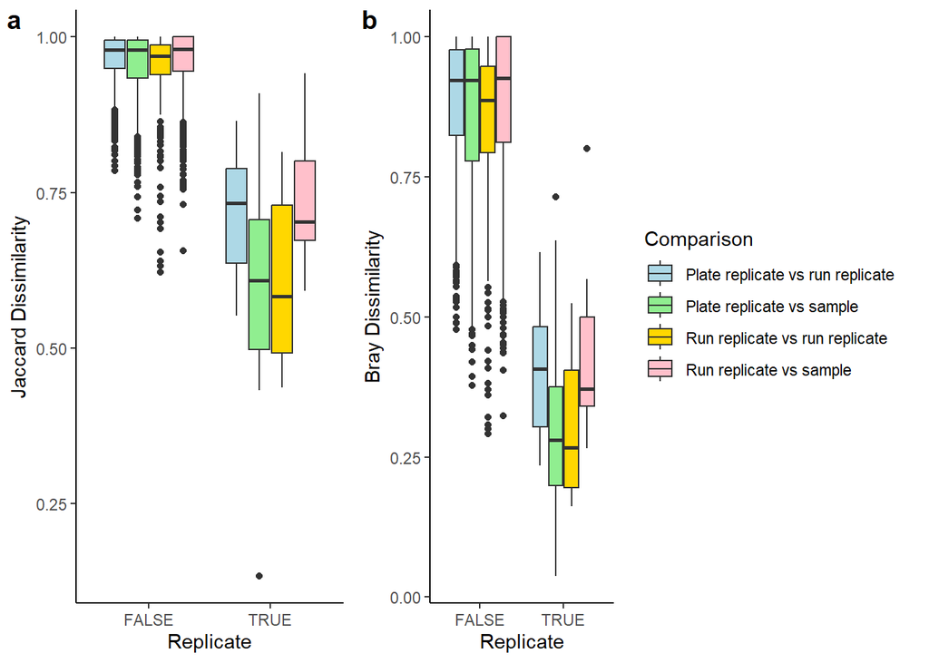

```r
types_boxplot <- cowplot::plot_grid(compare_reps_jaccard_types, compare_reps_bray_types, labels = c("a", "b"), ncol = 2, rel_widths = c(1.6, 2.6) )

types_boxplot
```

```r
ggsave(filename = "Figures/types_boxplot.png", plot = types_boxplot,
       device = "png", dpi = 300, units = "mm", height = 170, width = 250)
```

## Concluding remarks

We have now tidied, decontaminated, and filtered our eDNA metabarcoding data and used a variety of visualizations to quality check our data. Further ecological analyses will be presented in separate Markdown documents using the data generated in this workflow.